# Intermediate integration analysis notebook

Author

Joe Oddy

# 1 Data processing

The first steps in this notebook load the necessary libraries, source the data acquisition script, and process the data. This involves some separate processing of the different data modalities (e.g. scaling) before combining them into a single large matrix with the target variable (% of NK cells in sample) appended to this.

# 2 Specifying model design/hyperparameters

## 2.1 Pairwise sPLS models

In the first step, pairwise sparse PLS models are fit between each modality to explore the relationships between them. In these models, we use one modality to explain another and vice versa. The mode for spls is set to canonical:

“Canonical (mode =”canonical”): X and Y play symmetric roles. While not mathematically equivalent, the method is quite similar to CCA. It is appropriate to use when there is no a priori relationship between X and Y and as a replacement for CCA in very high dimensional contexts (when variables selection is desired). Y is deflated using information from Y.”

Correlations between the latent components are generally high (>0.8) (Figure 1 and Table 1). This information can be used to inform the design matrix used for the full DIABLO model.

**Overall correlations**

Figure 1

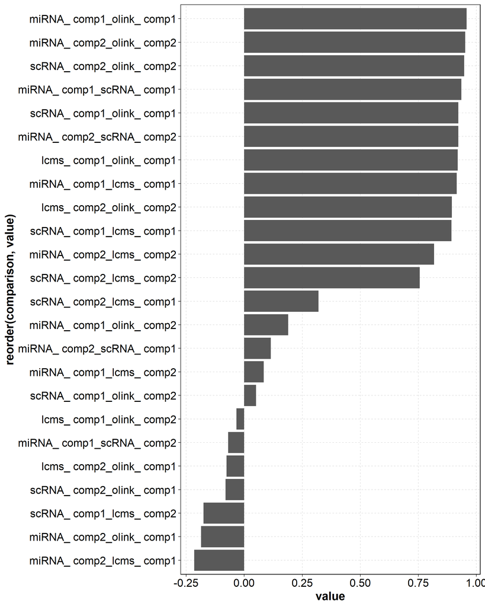

**Overall correlations - table**

Table 1

Pairwise correlations

| var1 | var2 | value |
| --- | --- | --- |
| miRNA_ comp1 | olink_ comp1 | 0.958277767309207 |
| miRNA_ comp2 | olink_ comp2 | 0.952017705251989 |
| scRNA_ comp2 | olink_ comp2 | 0.947874357728382 |
| miRNA_ comp1 | scRNA_ comp1 | 0.935405404654479 |
| scRNA_ comp1 | olink_ comp1 | 0.922599749719817 |
| miRNA_ comp2 | scRNA_ comp2 | 0.921967925826423 |
| lcms_ comp1 | olink_ comp1 | 0.919866249805686 |
| miRNA_ comp1 | lcms_ comp1 | 0.915566196875928 |
| lcms_ comp2 | olink_ comp2 | 0.894172337967405 |
| scRNA_ comp1 | lcms_ comp1 | 0.892693548392584 |

[output cut: 14 more lines]

## 2.2 Design

The block sPLS model implemented here does not have built-in capacity for tuning of the hyperparameters or assessment of model accuracy. Consequently, I used a block sPLS-DA model to select appropriate hyperparameters (ncomp and number of features to keep in each block), because these classification models do have tuning and performance assessment functions. For classification purposes, the NK_proportion data was encoded into four classes: < 25% NK, 25 - 50% NK, 50 - 75% NK, and > 75% NK. From this, the optimal number of components was 3 (based on mahalanobis distance) and the optimal number of features from each block to keep in each component are shown below in Table 2.

Table 2

Features retained from each modality

| modality | comp1 | comp2 | V3 |
| --- | --- | --- | --- |
| lcms | 5 | 15 | 5 |
| miRNA | 5 | 5 | 5 |
| olink | 15 | 15 | 5 |
| scRNA | 5 | 25 | 5 |

# 3 Cross-validated sPLS regression model

For this intermediate integration analysis, a simple five-fold cross-validation method (with 10 repeats) was used to assess performance because hyperparameter tuning is not possible with the mixOmics sPLS regression model.

The metrics are displayed in Figure 2.

## 3.1 Performance metrics - table

Performance metrics

| mean_R2 | sd_R2 | mean_RMSE | sd_RMSE | mean_MAE | sd_MAE |
| --- | --- | --- | --- | --- | --- |
| 0.784407442630164 | 0.246833190243154 | 0.174592746521951 | 0.10150680431865 | 0.128787799942834 | 0.077609674558619 |

## 3.2 Performance metrics - figure

Figure 2

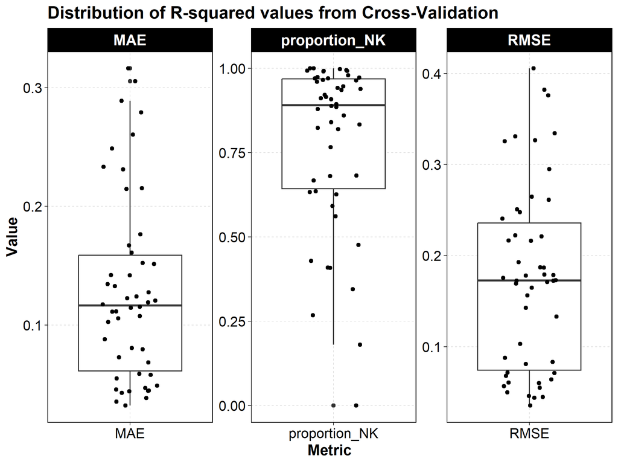

# 4 Feature importances

Having assessed the model using cross-validation, the final model is fit on the whole data set to find the most informative features. These are listed in Table 3 and loadings on component 1 are shown in Figure 3.

**Features from each omic**

Table 3

Features retained from each modality for comps 1 and 2

| value | component | omics |
| --- | --- | --- |
| ENSG00000207782 | 1 | miRNA |
| ENSG00000199150 | 1 | miRNA |
| ENSG00000275344 | 1 | miRNA |
| ENSG00000271886 | 1 | miRNA |
| ENSG00000208012 | 1 | miRNA |
| ENSG00000207933 | 2 | miRNA |
| ENSG00000207816 | 2 | miRNA |
| ENSG00000207598 | 2 | miRNA |
| ENSG00000208005 | 2 | miRNA |
| ENSG00000198997 | 2 | miRNA |

[output cut: 80 more lines]

**Feature importances**

Figure 3

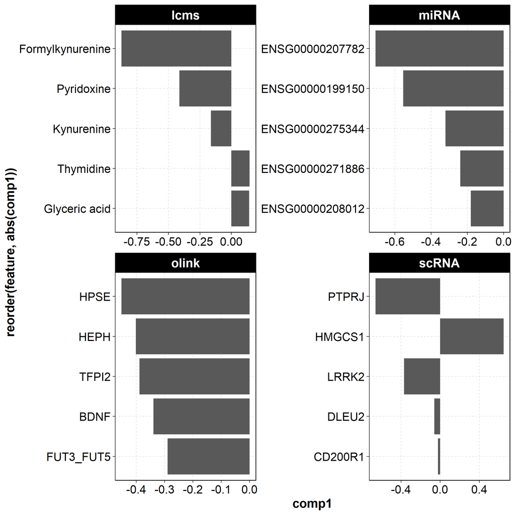